# Week 11 Lecture - Experimental Confounds

Undergraduate Research Methods in Psychology

Quinton Quagliano, M.S., C.S.P

Department of Psychology

# 1 Last Unit Review & Announcements

## 1.1 Announcements and Due Dates

- Don’t forget about the **reading evidence**!
- Article Critique and Research Proposal first drafts were due today - we are now into the final stretch. Make sure to be making consistent progress on your project work (**article critique and research proposal**) outside of class!
- I will have office hours again at 3:00pm - 6:00pm EST in AuSable 1307 on Friday 11/15/2024. Please consider coming if you have recently been struggling or would like to discuss the projects. I am available via email as well.

## 1.2 Last Unit Content

- We established the differences between between-subjects and within-subjects experimental designs, as well as their relative strengths and weaknesses
- We introduced critiquing causal claims and experiments with the four claim validities
- We spent some time working on developing some initial ideas about the quality and rigor of our article critiques.

# 2 Quiz 9 Review

## 2.1 Areas for Review

- For a multiple regression model, to *control* for other predictor variables is to statistically negate their effects from our coefficients. Thus, our beta coefficient ($\beta$) for any one of the predictors represents the effect of that variable on the outcome/criterion in *isolation* from the other predictors

# 3 Quiz 10

## 3.1 Quiz Content

- Covers all content from 11/04 class meeting, including but not limited to:
  - Chapter 10 of Morling Textbook
  - Lecture on Chapter 10
- *Any last minute questions?*

## 3.2 Quiz Rules

- *From the Syllabus:*
  - Each quiz is 10 multiple-choice questions, 1 point for each question
  - Quizzes will be taken at the start of the class period on the Blackboard LMS
  - Quizzes will be on content covered in the previous lecture and the associated reading for that lecture
  - Quizzes are timed, 23 minutes only (previously was 15 minutes). If you finish before time is up, please remain in class and find another activity to work on quietly
  - Quizzes are open-note and open-book, that is, you are allowed to use those resources during the quizzes. Thus, they reward good structure in thoughtfulness in your notes and preparation
  - You may not collaborate with others during the quizzes, or discuss questions with other students after the quiz. You cannot use AI tools or the internet to help you during the quiz
  - Quizzes and exam will be ended early if all students are clearly finished and content with their answers
  - Quizzes will be graded promptly and reviewed the following week

# 4 Learning Objectives

## 4.1 Textbook Objectives

- Interrogate a study and decide whether it rules out twelve potential threats to internal validity.
- Describe how researchers can design studies to prevent internal validity threats.
- Interrogate an experiment with a null result to decide whether the study design obscured an effect or whether there is truly no effect to find.
- Describe how researchers can design studies to minimize possible obscuring factors.

## 4.2 Professor’s Objectives

- Describe the importance of comparison groups in ruling out threats to validity
- Explain an example for each type of validity threat

# 5 Chapter Overview

## 5.1 Chapter Overview

- Because of the rigor required to investigate causal claims, we must be cautious of a number of internal validity threats
- We may have to be especially mindful in our design in order to ensure our finding are “real”. Design flaws may manifest as third variables.
- Failure to design around these threats may lead to confounds in our internal validity, and therefore, may hurt our claims

# 6 More Internal Validity Threats

## 6.1 Working Example

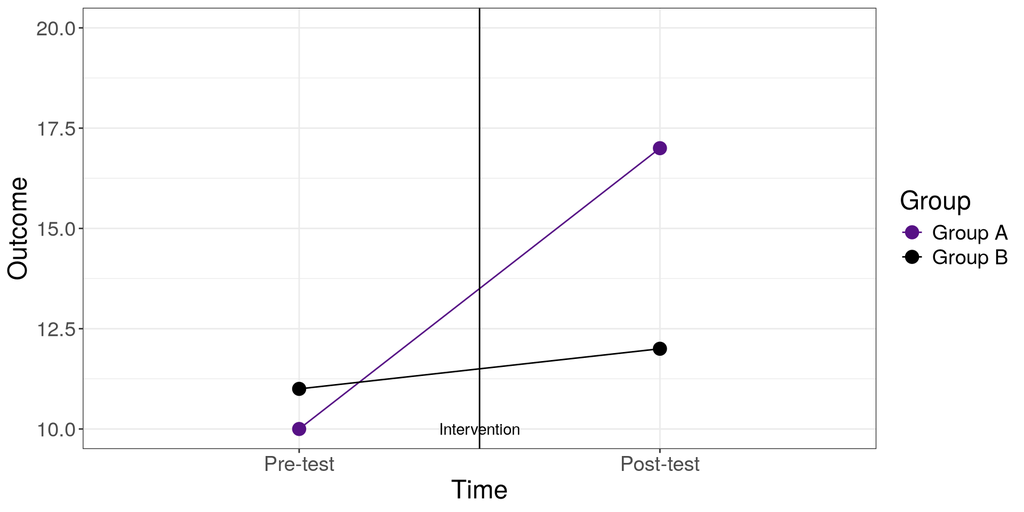

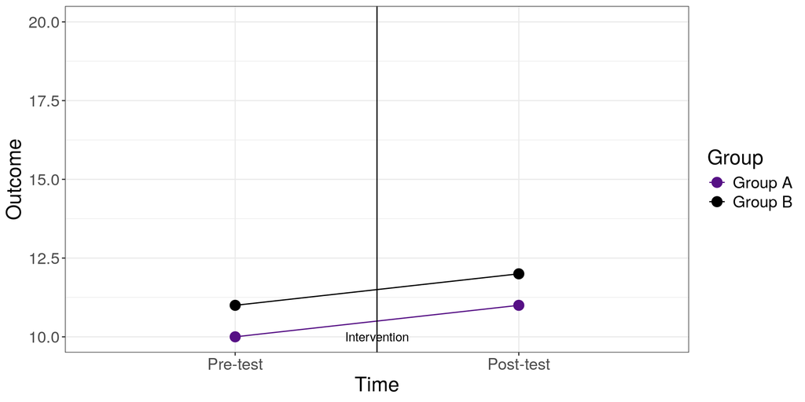

## 6.2 Overview

- We have already discussed selection effects, design confounds, and order effects - as well as how they impact the between-subjects and within-subjects designs differently
- These all result from a lack of random assignment not being implemented
- However, there are many other threats to also be concerned with…

## 6.3 For One-group & Pretest/Posttest Designs

- Some threats are a particular concern in our between-subjects designs:

### Maturation

- Certain behaviors may simply evaporate by themselves - we may describe this change as being “spontaneous” and unexpected
- This is change that is not explainable by our intervention or lack-thereof
- *Prevention:*
  - Our comparison group! Perhaps there is a maturation effect, but because we have a comparison group, we can see if there is a difference despite the maturation.
  - However, this can be most accurately demonstrated with a pretest/posttest design, to look at the trend of change over time.

### History

- An effect may occur due to some event that creates an unexpected change in our groups.
- However, to be a true history threat this must be systematic, i.e., happening in a outsized manner on only one of the groups.
- *Prevention:*
  - Once again, our comparison group saves the day! If both groups deal with the same event, then the effect is unsystematic and not of major concern for the differences between the groups.
  - However, if the event somehow has a biased impact on one group, the experiment may have to be re-done under “normal” conditions.

### Regression

- This threat revolves around regression to the mean, where, over time, extreme scores tend to naturally converge towards the central tendency of the data
- Thus, extremely high scores naturally trend downward as time passes, and extremely low scores naturally trend upward.
- *Prevention:*
  - Guess what saves us here? comparison groups! (Notice a trend?)
  - If we see groups equal at the start, and a difference in trend, we know that one group did indeed have an effect above and beyond the effects of regression.

### Differences Between Maturation, History, & Regression

- *Maturation* threats deal with *spontaneous and unexplainable* change in behavior
- *History* threats are due to a specific event or know outside environmental influence
- *Regression* threats come form naturally extreme scores converging on the mean or center of a scale.

### Attrition

- Attrition occurs whenever we have some systematic departure from our sample (may also be known as “mortality”)
- If attrition happens among all groups and types of people, then concern is low.
- But, If there is high attrition among one of the groups, we have a differential effect that could confound
- *Prevention:*
  - It is often impossible to fully prevent people from not completing the study (because research is voluntary !)
  - Instead, we may opt to listwise delete, or completely remove the data corresponding to those who dropped out.

### Testing

- As we learned with practice effects, participants may grow more skilled if they take an assessment more than once, not due to intervention, but just due to natural growth.
- *Prevention:*
  - Don’t use a pre-test - ironically, this makes investigating the other threats more difficult
  - Use two different, but equivalent forms of the same test! But how do we know they measure the same thing? $\rightarrow$ correlation!

### Instrumentation

- This occurs when something about the measurement instrument changes over time.
- Put another way, our measurement is not behaving reliably!
- *Prevention:*
  - We may use only a post-test design. The instrument can’t change over time if it is only used once!
  - We may use construct validity statistics (e.g., Cronbach's $\alpha$) to assess validity and reliability of the measures at both time points
  - We may counterbalance order of two different forms

### Combined Threats

- Our selection effects may combine with any of the threats described here, or even multiple threats may be present.
- As a general rule, we are looking for sources of systematic variability that may affect one comparison group, but *not* the other.

## 6.4 Any Study

- Even with good and proper use of comparison groups, we are not entirely out of the woods of threats.

### Observer Bias

- When we described observational measures, we broached the problem of potential bias in how our research observers perceive and record measurements.
- This is still a major concern in experiments, even despite the rigorous procedures - effectively, a part of construct validity impacts the internal validity
- **Prevention:**
  - Remember to blind your observers, i.e., make them unaware of the experiments groups and purpose prior to the recording.

### Demand Characteristics

- *Review:* a demand characteristic is when a participant changes their behavior un-naturally due to understanding then nature of the experiment
- *Prevention:*
  - Ideally, both participants and observers should be blinded to study goals and hypotheses, to prevent possible confounds from arising.
  - Little detail about the conditions should be shared until debriefing

### Placebo Effect

- Placebo effects occur when the mere belief in a treatment produces a pronounced positive effect - this is *extremely common*
- *Prevention:*
  - We can use double-blinding and measure whether the real group sees a more pronounced effect than the placebo group

## 6.5 Validity in the Face of Many Threats

- Despite the numerous challenges discussed above, experiments are still valuable and rigorous designs
- A comparison group already does wonders for preventing many of the threats discussed, and further issues can usually be addressed with specific attention paid to the prevention methods above.

# 7 Null Effects

## 7.1 Overview

- Sometimes, we don't find a difference where we expect, as evidenced by a p > 0.05 or a 95% CI that contains 0. What gives?!
- This is actually very common in research, and not necessarily indicative of something having been done wrong.
- However, we should investigate whether changes to the design would have changed the statistical significance of the results

## 7.2 Not Enough Differences Between Groups

- One root cause of having null effects is having insufficient evidence of difference between the independent variable conditions.

### Weak Manipulation

- It is possible that our manipulation (i.e., the difference between the two conditions) is simply not impactful enough to create a difference in outcome.
- Put another way, the way we operationalized our construct of interest was insufficient

### Insensitive Measures

- We may have the reverse problem: where our manipulation is impactful, but our dependent variable measure is not sensitive enough to detect it.
- Here, we may need to consider using a continuous measure that is detailed enough to capture change in the outcome.

### Ceiling and Floor Effect

- A **ceiling effect** happens when most participants have a score close to the top end of possible scores on the outcome measure.
- Inversely, a **floor effect** is when most scores are clustered towards the bottom of possible scores.
- These are symptoms of a flawed measure, and will often result in means that are close together, regardless of condition.

### Value in Manipulation Checks

- We alluded to **manipulation checks** before, which offer some way to assess whether a manipulation truly caused any sort of change. This is often some additional variable we measure alongside the outcome.

### Reverse Design Confound

- A design confound may confuse the results of an experiment in the opposite direction of the effect of the intervention, thus causing the appearance of null results.

## 7.3 Too Much Within-group Variation

- It may be that we do have a difference between our groups, but the variance within each condition is so large (i.e., noise or error) that it becomes difficult to determine.
- This often manifests as large standard errors / wide confidence intervals.

### Measurement Error

- Measurement error naturally occurs in every instrument, but our goal is to limit this as much as possible.
- A Formula:

$$Observed = True + Error$$

- *The solution:*
  - Ideally: Use better tools! e.g., recall chapter 5 and our various assessments of measurement reliability and validity
  - Less ideal: Just measure more people! The inconsistency will balance out naturally (probably)

### Individual Differences

- As previously stated, research is probabilistic, in other words, we capture general trends and mean differences. However, salient-enough individual differences can confuse between groups effects.
- *The solution:*
  - Bigger sample! This dilutes the effects of individuals with odd or unusual characteristics within each group
  - Use a within-subject design, then each person’s trait controls for themselves!

### Situation Noise

- This is a much more real type of noise, in which the literal environment of the experiment may be playing some un-intended role in the outcome variable.
- This is why many experiments are done in barren, boring lab settings.

## 7.4 Statistical Power

- **Power**, in research, refers to the likelihood that a significant effect is found, when that difference is real.
- Ideally, we employ methods that lend themselves to a high amount of power such as:
  - Within-groups designs
  - Larger samples
  - Sensitive measures
  - Low “noise” and high control
- In addition to helping us get significant results, this also aids in the reproducability of the study.

## 7.5 Transparency About Null Effects

- *A misconception:* Non-significant effects are not worth reporting.
- Null findings are informative to the process of self-correcting science

[figure not shown]

Week 11 Lecture - Experimental Confounds || Undergraduate Research Methods in Psychology